# R Notebook

```r
library(readxl)
library(tidyverse)
```

Zaczynamy od wczytnia danych

| sex | age | class | fc11 | fp29 | fp55 | fp56 | fp65 |
| --- | --- | --- | --- | --- | --- | --- | --- |
| 1 | 34 | 1 | 2 | 1 | 184 | 90 | 3000 |
| 1 | 48 | 1 | 4 | 1 | 180 | 90 | 2000 |
| 1 | 59 | 1 | 2 | 1 | 178 | 90 | 3000 |
| 1 | 55 | 1 | 2 | 1 | 174 | 85 | 1900 |
| 1 | 22 | 1 | 1 | 1 | 190 | 80 | 1100 |
| 1 | 51 | 1 | 2 | 2 | 190 | 90 | 3000 |
| 1 | 35 | 1 | 2 | 2 | 185 | 90 | 3000 |
| 1 | 36 | 1 | 1 | 1 | 183 | 75 | 3000 |
| 1 | 47 | 1 | 2 | 1 | 182 | 80 | 3000 |
| 1 | 34 | 1 | 1 | 1 | 175 | 72 | 1200 |

[output cut: 990 more lines]

## Exercise 1.

1 single 2 married 3 widow 4 divorced 5 legal separation 6 actual separation

```r
table(dane$fc11)
```

```
   1    2    3    4    5    6
 340 1062   47   49    5    7
```

Odpowiedź: 1062 married persons took part in the survey (variable fc11).

# Exercise 2.

The average age (variable age) of married persons (variable fc11) was ………..years

```r
dane_zwiazek <- dane %>% filter(fc11 == 2)
mean(dane_zwiazek$age)
```

```
[1] 44.83427
```

| m |
| --- |
| 44.83427 |

| fc11 | age |
| --- | --- |
| 1 | 31.25588 |
| 2 | 44.83427 |
| 3 | 56.00000 |
| 4 | 48.67347 |
| 5 | 46.60000 |
| 6 | 45.57143 |

```r
mean(dane$age[dane$fc11 == 2])
```

```
[1] 44.83427
```

The average age (variable age) of married persons (variable fc11) was 44.8 years

# Exercise 3.

| sex | fp65 |
| --- | --- |
| 1 | 200 |
| 2 | 50 |

| min | max | mean | sd | median |
| --- | --- | --- | --- | --- |
| 200 | 30000 | 2251.423 | 1898.573 | 2000 |

Compute basic descripive statistics of income (variable fp65) (min, max, mean, standard deviaKon and median) for males (variable sex). [2p]

Min=200 Max= 30000 Mean= 2251.423 Sd= 1898.573 Median=2000

# Exercise 4.

Complete the following conKngency table, which contains informaKon about the number of respondents by class of locality (variable class) and the variable fp29 (What is more important in your life?).

```r
xtabs(~ class + fp29, dat = dane)
```

```
     fp29
class   1   2
    1  59  83
    2  60  76
    3  45  56
    4 123 139
    5  90 108
    6 288 383
```

```r
table(dane$class, dane$fp29)
```

```
      1   2
  1  59  83
  2  60  76
  3  45  56
  4 123 139
  5  90 108
  6 288 383
```

| class | 1 | 2 |
| --- | --- | --- |
| 1 | 59 | 83 |
| 2 | 60 | 76 |
| 3 | 45 | 56 |
| 4 | 123 | 139 |
| 5 | 90 | 108 |
| 6 | 288 | 383 |

# Exercise 5.

Recode variable age into two levels: 1 – up to 35 years (including 35), 2 – above 35 years and fill in the table below with frequencies. [2p]

```r
xtabs(~ sex + wiek, dane)
```

```
   wiek
sex   1   2
  1 260 555
  2 225 470
```

# Exercise 6.

Complete informaKon about the percentage of respondents by marital status (variable fc11) by entering the appropriate values above each bar separately.

```r
table(dane$fc11) / nrow(dane) * 100
```

```
         1          2          3          4          5          6
22.5165563 70.3311258  3.1125828  3.2450331  0.3311258  0.4635762
```

```r
prop.table(table(dane$fc11))*100
```

```
         1          2          3          4          5          6
22.5165563 70.3311258  3.1125828  3.2450331  0.3311258  0.4635762
```

| fc11 | n | p |
| --- | --- | --- |
| 1 | 340 | 22.5165563 |
| 2 | 1062 | 70.3311258 |
| 3 | 47 | 3.1125828 |
| 4 | 49 | 3.2450331 |
| 5 | 5 | 0.3311258 |
| 6 | 7 | 0.4635762 |

# Exercise 7.

Compute and interpret the Pearson coefficient of correlaKon between height (variable fp55) and weight (variable fp56) for males (variable sex) living in 500T+ ciKes (variable class).

```r
cor(mez_city$fp55, mez_city$fp56)
```

```
[1] 0.2189907
```

| cor |
| --- |
| 0.2189907 |

```r
cor(dane[dane$sex ==1 & dane$class == 1, c("fp55", "fp56")], method = "pearson")
```

```
          fp55      fp56
fp55 1.0000000 0.2189907
fp56 0.2189907 1.0000000
```

# Exercise 8.

QuarKles of height (variable fp55) for females (variable sex) are equal to: [2p]

Q1=…………………. Q2=…………………. Q3=………………….

```r
quantile(x = dane$fp55[dane$sex == 2])
```

```
  0%  25%  50%  75% 100%
 142  160  164  168  186
```

| q1 | q2 | q3 |
| --- | --- | --- |
| 160 | 164 | 168 |

# Exercise 9.

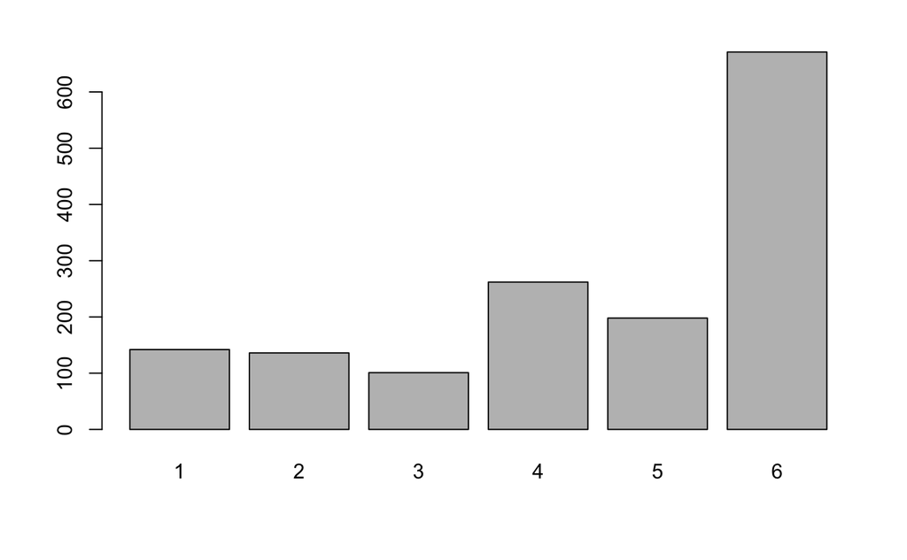

# Exercise 10.

Write an R funcKon which for a given radius r returns the surface area of the ball

```r
licz_pow_i_obj <- function(r) {

  wynik <- c(pow = 4*pi*r^2, obj = 4/3*pi*r^3)

  return(wynik)
}
```

```r
licz_pow_i_obj(10)
```

```
     pow      obj
1256.637 4188.790
```